# Reproducible Research HW1

Zachary Palmore

September 7, 2018

## Rice Rivers Data

In this *Markdown document*, which will be used from now until the end of time, I will be creating a summary of data taken from the Rice Center. The **intent** of this homework is to figure out how to **manipulate data** and begin experimenting with the basics of **generating summaries, tables, plots, common writing and font styles.**

### Rice River Summary

```r
require(RCurl)
long_link <- c( "https://docs.google.com/spreadsheets/d",
"/1Mk1YGH9LqjF7drJE-td1G_JkdADOU0eMlrP01WFBT8s",
"/pub?gid=0&single=true&output=csv"
)

link <- paste(long_link, collapse="")
url <- getURL( link )
con <- textConnection( url)
RiceData <- read.csv(con)
summary(RiceData)
```

```
##                 DateTime       RecordID          PAR
##  1/1/2014 1:00:00 AM:   1   Min.   :43816   Min.   :   0.000
##  1/1/2014 1:00:00 PM:   1   1st Qu.:45866   1st Qu.:   0.000
##  1/1/2014 1:15:00 AM:   1   Median :47915   Median :   0.046
##  1/1/2014 1:15:00 PM:   1   Mean   :47915   Mean   : 241.984
##  1/1/2014 1:30:00 AM:   1   3rd Qu.:49965   3rd Qu.: 337.900
##  1/1/2014 1:30:00 PM:   1   Max.   :52014   Max.   :1957.000
##  (Other)            :8193
##  WindSpeed_mph       WindDir          AirTempF       RelHumidity
##  Min.   : 0.000   Min.   :  0.00   Min.   : 3.749   Min.   :15.37
##  1st Qu.: 2.467   1st Qu.: 37.31   1st Qu.:31.545   1st Qu.:42.25
##  Median : 4.090   Median :137.30   Median :37.440   Median :56.40
##  Mean   : 5.446   Mean   :146.20   Mean   :38.795   Mean   :58.37
##  3rd Qu.: 7.292   3rd Qu.:249.95   3rd Qu.:46.410   3rd Qu.:76.59
##  Max.   :30.650   Max.   :360.00   Max.   :74.870   Max.   :93.00
##
##      BP_HG          Rain_in            H2O_TempC       SpCond_mScm
##  Min.   :29.11   Min.   :0.0000000   Min.   :-0.140   Min.   :0.0110
##  1st Qu.:29.87   1st Qu.:0.0000000   1st Qu.: 3.930   1st Qu.:0.1430
##  Median :30.01   Median :0.0000000   Median : 5.450   Median :0.1650
##  Mean   :30.02   Mean   :0.0008412   Mean   : 5.529   Mean   :0.1611
##  3rd Qu.:30.21   3rd Qu.:0.0000000   3rd Qu.: 7.410   3rd Qu.:0.1760
##  Max.   :30.58   Max.   :0.3470000   Max.   :13.300   Max.   :0.2110
##                                      NA's   :1        NA's   :1
##   Salinity_ppt          PH           PH_mv        Turbidity_ntu
##  Min.   :0.0000   Min.   :6.43   Min.   :-113.8   Min.   :  6.20
##  1st Qu.:0.0700   1st Qu.:7.50   1st Qu.: -47.8   1st Qu.: 15.50
##  Median :0.0800   Median :7.58   Median : -43.8   Median : 21.80
##  Mean   :0.0759   Mean   :7.60   Mean   : -44.5   Mean   : 24.54
##  3rd Qu.:0.0800   3rd Qu.:7.69   3rd Qu.: -38.9   3rd Qu.: 30.30
##  Max.   :0.1000   Max.   :9.00   Max.   :  28.5   Max.   :187.70
##  NA's   :1        NA's   :1      NA's   :1        NA's   :1
##     Chla_ugl       BGAPC_CML        BGAPC_rfu         ODO_sat
##  Min.   :  1.3   Min.   :   188   Min.   :  0.10   Min.   : 87.5
##  1st Qu.:  3.7   1st Qu.:   971   1st Qu.:  0.50   1st Qu.: 99.2
##  Median :  6.7   Median :  1369   Median :  0.70   Median :101.8
##  Mean   :137.3   Mean   :153571   Mean   : 72.91   Mean   :102.0
##  3rd Qu.:302.6   3rd Qu.:345211   3rd Qu.:163.60   3rd Qu.:104.1
##  Max.   :330.1   Max.   :345471   Max.   :163.70   Max.   :120.8
##  NA's   :1       NA's   :1        NA's   :1        NA's   :1
##     ODO_mgl         Depth_ft        Depth_m
##  Min.   :10.34   Min.   :12.15   Min.   :3.705
##  1st Qu.:12.34   1st Qu.:14.60   1st Qu.:4.451
##  Median :12.88   Median :15.37   Median :4.684
##  Mean   :12.88   Mean   :15.34   Mean   :4.677
##  3rd Qu.:13.34   3rd Qu.:16.12   3rd Qu.:4.913
##  Max.   :14.99   Max.   :17.89   Max.   :5.454
##  NA's   :1
##  SurfaceWaterElev_m_levelNad83m
##  Min.   :-32.53
##  1st Qu.:-31.78
##  Median :-31.55
##  Mean   :-31.55
##  3rd Qu.:-31.32
##  Max.   :-30.78
##
```

## Rice Plots

Each of the following two plots contain the code displayed to demonstrate that the `echo = True` parameters was used correctly. Code is read by R programming language to display these plots. Whether these plots were coded correctly however, remains to be seen.

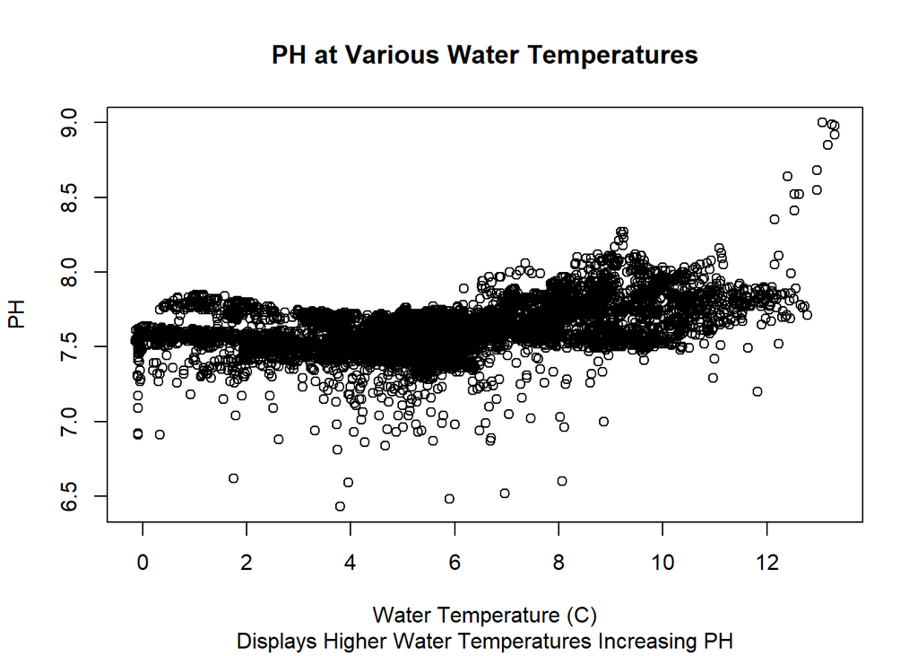

```r
plot(RiceData$H2O_TempC,RiceData$PH,
     xlab = "Water Temperature (C)",
     ylab = "PH",
     main = "PH at Various Water Temperatures",
     sub = "Displays Higher Water Temperatures Increasing PH")
```

Here is the second plot where fluffery is continued and this fake manuscript dives deeper into new realms of craziness. Call it figure 2 categorized as *The Savant Child*

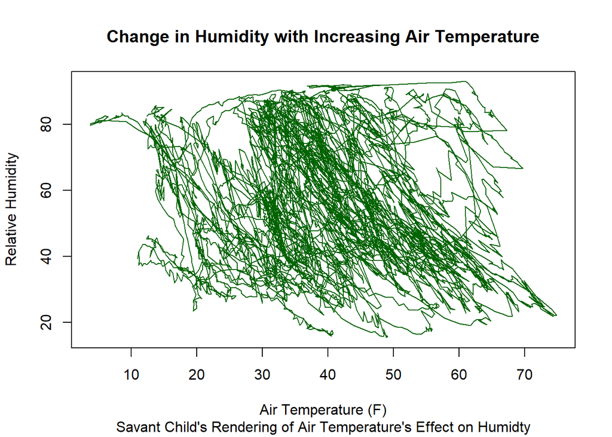

```r
plot(RiceData$AirTempF,RiceData$RelHumidity,
     xlab = "Air Temperature (F)",
     ylab = "Relative Humidity",
     main = "Change in Humidity with Increasing Air Temperature",
     sub = "Savant Child's Rendering of Air Temperature's Effect on Humidty",
     type = "l",
     col = "dark green"
     )
```

Important to remember so that the professor may help me with my screwups is the `echo = True` parameter. This was added to ensure the code chunk to printed itself into the document and demonstrates the code to create my summary, plots, and table.

## Table

Ah Yes, the hardest part of any fake manuscript, creating tables in R. This should be fun. What could possibly go wrong?

```r
head(RiceData, n=10)
```

```
##                DateTime RecordID PAR WindSpeed_mph WindDir AirTempF
## 1  1/1/2014 12:00:00 AM    43816   0         3.870   14.58    30.99
## 2  1/1/2014 12:15:00 AM    43817   0         4.787   18.53    30.72
## 3  1/1/2014 12:30:00 AM    43818   0         3.614   16.16    31.22
## 4  1/1/2014 12:45:00 AM    43819   0         2.986   11.47    30.54
## 5   1/1/2014 1:00:00 AM    43820   0         3.522   11.31    30.93
## 6   1/1/2014 1:15:00 AM    43821   0         3.827   20.02    30.61
## 7   1/1/2014 1:30:00 AM    43822   0         4.234   12.53    30.20
## 8   1/1/2014 1:45:00 AM    43823   0         4.379   16.28    30.33
## 9   1/1/2014 2:00:00 AM    43824   0         4.037   19.04    30.87
## 10  1/1/2014 2:15:00 AM    43825   0         3.637   29.40    31.94
##    RelHumidity BP_HG Rain_in H2O_TempC SpCond_mScm Salinity_ppt   PH PH_mv
## 1        80.50 30.30       0      6.44       0.130         0.06 7.22 -10.9
## 2        82.10 30.30       0      6.49       0.137         0.06 7.52 -26.8
## 3        81.90 30.29       0      6.38       0.134         0.06 7.53 -27.4
```

[output cut: 29 more lines]

#### Data, Methods, and Other Pertinent Information

Processing of Rice data into a table was the most difficult and went something like this:

```
With the help of Hadley Whickam, author of dplyr and ggplot2 at https://www.cyclismo.org/tutorial/R/tables.html, the following table was generated. Then, practicing input of basic idea of inputing variables and given the columns and rows names data, this was created using the following code.
```

```r
FakeTable <- matrix(c(11,343,3342,18,190,330,18,2,99,10,20,30,40,50,001001,01101201,1001,01,02,03), ncol=4, byrow=TRUE)
colnames(FakeTable) <- c("High","Low","Former","Greatest")
rownames(FakeTable) <- c("Super Current","Current","Former","Partially Quit","Never")
FakeTable <- as.table(FakeTable)
FakeTable
```

```
##                   High     Low  Former Greatest
## Super Current       11     343    3342       18
## Current            190     330      18        2
## Former              99      10      20       30
## Partially Quit      40      50    1001  1101201
## Never             1001       1       2        3
```

Eventually, the proper coding formula was derived from the combination of information from the website https://www.statmethods.net/input/contents.html, re-reading class documents (over and over), then referring to Rstudio’s help feature multiple times a session on repeat (for replicability) playing with the programs until something close to what was generated popped up. This gave the results needed to complete this homework assignement. What’s next?

## Discussion

In the future, the best possible method of figuring out how to do something already created (not reinventing the wheel/program), might be to reference completed works (such as my own).

## References

Links are easy and in no way would this fly on a manuscript, but do they really work when knitted to an html format? Of course they do! R markdown is meant to be easy (sort of).

https://cran.r-project.org/web/packages/qwraps2/vignettes/summary-statistics.html

https://www.statmethods.net/input/contents.html

https://www.cyclismo.org/tutorial/R/tables.html

## Considerations

Rodney J. Dyer | Jane L. Remefert | Mattew G. DeSaix | Bonnie Roderique | Megan Keuchle | Jack |

Dyer Lab Rules!